# Population Genetic Structure Part 1 of 2

Apollo Lizano; Le Qin Choo

2025-03-31

List of softwares: vcftools plink admixture bcftools

## Introduction

In this practical we will be analysing population structure in a genomic dataset. By the end of the practical you should be able to employ some commonly used methods (FST, admixture, PCA) to detect and quantify population structure. We will also continue to develop our plotting skills in R.

## The data

We will be using a large SNP dataset from target-capture sequencing data of fast-growing and slow-growing milkfish from two different broodstock source populations to explore genomic structure based on location and growth phenotypes. The data are stored as zipped vcf files `.vcf.gz` in your `Day_02` directory.

### 1. Population Structure: PCA

Now that we have a fully filtered VCF, we can start do some cool analyses with it. First of all we will investigate population structure using principal components analysis.

Examining population structure can give us a great deal of insight into the history and origin of populations. Model-free methods for examining population structure and ancestry, such as principal components analysis are extremely popular in population genomic research. This is because it is typically simple to apply and relatively easy to interpret.

Essentially, PCA aims to identify the main axes of variation in a dataset with each axis being independent of the next (i.e. there should be no correlation between them). The first component summarizes the major axis variation and the second the next largest and so on, until cumulatively all the available variation is explained. In the context of genetic data, PCA summarizes the major axes of variation in allele frequencies and then produces the coordinates of individuals along these axes.

To perform a PCA on our milkfsih data, we will use `plink` - specifically version 1.9 (although be aware older and newer versions are available). Note that plink was originally written with human data in mind and has also subsequently been extended to include some model species. As a result, we need to provide a bit of extra info to get it to work on our dataset.

#### 1.1. Linkage Pruning

One of the major assumptions of PCA is that the data we use is indpendent - i.e. there are no spurious correlations among the measured variables. This is obviously not the case for most genomic data as allele frequencies are correlated due to physical linkage and linkage disequilibrium. So as a first step, we need to prune our dataset of variants that are in linkage.

First things first, we will make a directory called `plink`

```bash
mkdir plink

# move into it
cd plink
```

We will also simplify our code using some environmental variables. Primarily we set one for our filtered VCF.

Create another shell script:

```bash
#!/bin/bash

VCF=/home/apl/NAS_apl/milkfish/full_filter_nomaf_milkfish_snps_filtered.vcf.gz ##path to your filtered SNPs file .vcf.gz

#perform linkage pruning - i.e. identify prune sites
plink --vcf $VCF --double-id --allow-extra-chr 0 \
--set-missing-var-ids @:# \
--indep-pairwise 50 10 0.1 --out milkfish_nomaf
```

This will make it very easy for plink to read in our data. Next we run the linkage pruning. Run the command and we will breakdown what all the arguments mean.

So for our plink command, we did the following:

–vcf - specified the location of our VCF file.

–double-id - told plink to duplicate the id of our samples (this is because plink typically expects a family and individual id - i.e. for pedigree data - this is not necessary for us.

–allow-extra-chr - allow additional chromosomes beyond the human chromosome set. This is necessary as otherwise plink expects chromosomes 1-22 and the human X chromosome.

–set-missing-var-ids - also necessary to set a variant ID for our SNPs. Human and model organisms often have annotated SNP names and so plink will look for these. We do not have them so instead we set ours to default to chromosome:position which can be achieved in plink by setting the option @:# - see here for more info.

–out Produce the prefix for the output data.

As well as being versatile, `plink` is very fast. It will quickly produce a linkage analysis for all our data and write plenty of information to the screen. When complete, it will write out two files milkfish_nomaf.prune.in and milkfish_nomaf.prune.out. The first of these is a list of sites which fell below our linkage threshold - i.e. those we should retain. The other file is the opposite of this. In the next step, we will produce a PCA from these linkage-pruned sites.

### Now we are ready to perform a PCA

#### 1.2. Perform a PCA

Next we rerun `plink` with a few additional arguments to get it to conduct a PCA. We will run the command and then break it down as it is running.

Create another run of `plink` on the same shell script that you made.

```bash
# prune and create pca
plink --vcf $VCF --double-id --allow-extra-chr 0 --set-missing-var-ids @:# \
--extract milkfish_nomaf.prune.in \
--make-bed --pca --out milkfish_nomaf_pca
```

This is very similar to our previous command. What did we do here?

–extract - this just lets plink know we want to extract only these positions from our VCF - in other words, the analysis will only be conducted on these.

–make-bed - this is necessary to write out some additional files for another type of population structure analysis -a model based approach with admixture.

–pca - fairly self explanatory, this tells plink to calculate a principal components analysis. Once the command is run, we will see a series of new files. We will break these down too:

How many SNPs are left?

##### PCA output

milkfish_nomaf_pca.eigenval - the eigenvalues from our analysis milkfish_nomaf_pca.eigenvec- the eigenvectors from our analysis

plink binary output

milkfish_nomaf.bed - the mikfish bed file - this is a binary file necessary for admixture analysis. It is essentially the genotypes of the pruned dataset recoded as 1s and 0s.

milkfish_nomaf.bim - a map file (i.e. information file) of the variants contained in the bed file. milkfish_nomaf.fam - a map file for the individuals contained in the bed file.

##### Plotting the PCA output

Next we turn to R studio to plot the analysis we have produced!

##### Setting up the environment

First load the `tidyverse` package and ensure you have moved the `plink` output into the working directory you are operating in on your R studio.

Do you know how to transfer files from the server to your computer using `sftp`.

First go to the folder you want the files to be saved in your computer using `terminal´. Then run:

```bash
sftp apl@158.39.30.178 #(server address) click Enter then put the password given to you.

#cd to the path where the file you wanted to download is located

cd /home/apl/NAS_apl/milkfish

#use get file you wanted to download. This case we wanted to download two files: .eigenvec and .eigenval
#Note: Use put to put things in the server

get milkfish_filtered_PrunedUnrel_pca.eigenvec
get milkfish_filtered_PrunedUnrel_pca.eigenval

#remember that you cannot use the tab function while you are on sftp mode
```

Go back to your R studio

```r
# load tidyverse package
library(tidyverse)
```

Then we will use a combination of `readr` and the standard scan function to read in the data.

```r
# read in data
pca <- read_table2("milkfish_filtered_PrunedUnrel_pca.eigenvec", col_names = FALSE)
eigenval <- scan("milkfish_filtered_PrunedUnrel_pca.eigenval")
```

##### Cleaning up the data

Unfortunately, we need to do a bit of legwork to get our data into reasonable shape. First we will remove a nuisance column (plink outputs the individual ID twice). We will also give our pca data.frame proper column names.

```r
# sort out the pca data
# remove nuisance column
pca <- pca[,-1]
# set names
names(pca)[1] <- "ind"
names(pca)[2:ncol(pca)] <- paste0("PC", 1:(ncol(pca)-1))
```

Next we can add a species, location and if required, a species x location vector. We will do this using the R version of grep. We then use paste0 to combine the columns.

```r
# sort out the individual species and pops
# spp

spp <- rep(NA, length(pca$ind))
spp[grep("Pop-A-L", pca$ind)] <- "milkfish_Large"
spp[grep("Pop-A-S", pca$ind)] <- "milkfish_Small"
spp[grep("PopC-L", pca$ind)] <- "milkfish_Large"
spp[grep("PopC-S", pca$ind)] <- "milkfish_Small"
# location
loc <- rep(NA, length(pca$ind))
loc[grep("Pop-A", pca$ind)] <- "PopA"
loc[grep("PopC", pca$ind)] <- "PopC"
```

With these variables created, we can remake our data.frame like so. Note the use of `as.tibble` to ensure that we make a tibble for easy summaries etc.

```r
# combine - if you want to plot each in different colours
spp_loc <- paste0(spp, "_", loc)
```

```r
# remake data.frame
pca <- as_tibble(data.frame(pca, loc ))
```

##### Plotting the data

Now that we have done our housekeeping, we have everything in place to actually visualise the data properly. First we will plot the eigenvalues. It is quite straightforward to translate these into percentage variance explained (although note, you could just plot these raw if you wished).

```r
# first convert to percentage variance explained
pve <- data.frame(PC = 1:4, pve = eigenval/sum(eigenval)*100)

# Here we only include information from the first 4 PCs
```

With that done, it is very simple to create a bar plot showing the percentage of variance each principal component explains.

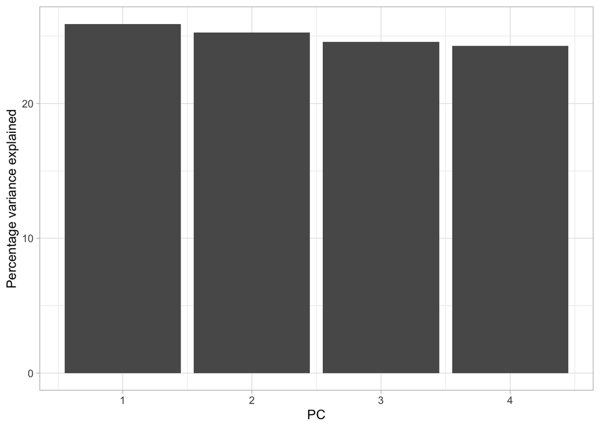

```r
# make plot
a <- ggplot(pve, aes(PC, pve)) + geom_bar(stat = "identity")
a + ylab("Percentage variance explained") + theme_light()
```

```r
# calculate the cumulative sum of the percentage variance explained
cumsum(pve$pve)
```

```
## [1]  25.89852  51.15706  75.71801 100.00000
```

Next we move on to actually plotting our PCA. Given the work we did earlier to get our data into shape, this doesn’t take much effort at all.

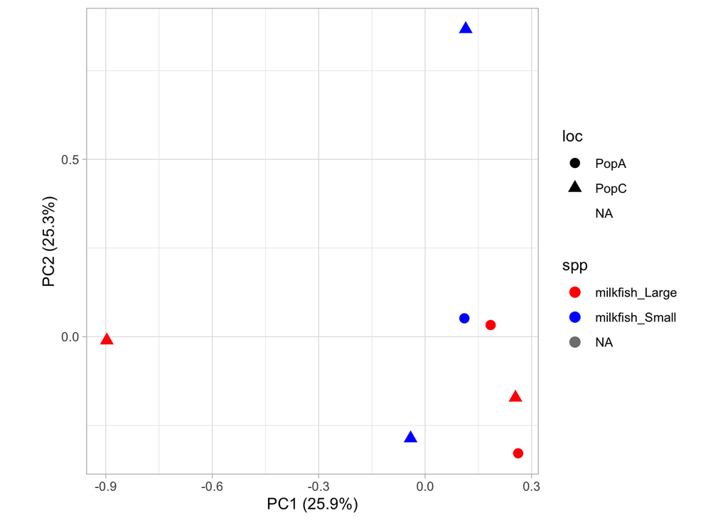

```r
# plot pca
b <- ggplot(pca, aes(PC1, PC2, col = spp, shape = loc)) + geom_point(size = 3)
b <- b + scale_colour_manual(values = c("red", "blue"))
b <- b + coord_equal() + theme_light()
b + xlab(paste0("PC1 (", signif(pve$pve[1], 3), "%)")) + ylab(paste0("PC2 (", signif(pve$pve[2], 3), "%)"))
```

Note that this R code block also includes arguments to display the percentage of variance explained on each axis. Here we only plot `PC1` and `PC2`. From this figure, what can you interpret?

### Why is there a missing individual? What do we need to do to trouble shoot? Can you try?

#### Take note that this is not the actual data (we did subset) so do not worry so much about the actual result. The most important thing is that you were able to ran all the commands properly.

### 2. Admixture

`ADMIXTURE` is a clustering software similar to STRUCTURE with the aim to infer populations and individual ancestries.

Finally, we are going to run Admixture on our dataset. But first we need to do one more piece of cleaning. We still have a very large number of SNPs in our milkfsih dataset, and with this many individuals and SNPs it would take Admixture several hours to run. So we are going to thin our markers substantially only for the purpose of this practical. Can you figure out, using `plink`, how to randomly select 10% of your markers and write them to a new file?

```bash
plink --bfile milkfish_filtered_PrunedUnrel --thin 0.1 --make-bed --out milkfish_filtered_thinned_prunedUnrel
```

How many SNPs are left?

Now look up the admixture manual online. The software has been installed on the server, and can be called up by typing `admixture`. If you do this, you will see that at its most basic level you just need an input file and a value of K. We will stick with the program defaults for now. Try running admixture at k = 2 for your cleaned `milkfish_filtered_thinned` dataset, using the following code.

```bash
mkdir admixture_milkfish #So current directory doesn't get too messy
cd admixture_milkfish
admixture ../milkfish_filtered_thinned_prunedUnrel.bed 2
```

Have a look at your outputs - you should see a file ending in `.P`, and one ending in `.Q`. Explore these files and see if you can figure out what each one is.

Typically with software like `STRUCTURE` or `admixture`, we wish to compare how genetic variation is structured across multiple values of k - usually from k = 2 to k = N populations

We could do this by repeating the above command 8 times, with k ranging from 2 to 9. But a more efficient way would be to create a for loop in bash. *Can you figure out how to do this?*

```bash
#!/bin/bash

for K in `seq 2 4`;
do
 /home/apl/NAS_apl/milkfish/plink/admixture/releases/admixture_linux-1.3.0/admixture /home/apl/NAS_apl/milkfish/plink/milkfish_filtered_thinned_prunedUnrel.bed $K;
done
```

### Did it work?

Tips: You need to specify the right path. Do not just copy paste :)

### Identifying the best K-value

To identify the best value of k clusters which is the value with lowest `cross-validation error`, we need to collect the cv errors. Below are three different ways to extract the number of K and the CV error for each corresponding K. Like we said at the start of the course, there are many ways to achieve the same thing in bioinformatics!

```bash
#1.
awk '/CV/ {print $3,$4}' *out | cut -c 4,7-20 > $FILE.cv.error

#2.
grep "CV" *out | awk '{print $3,$4}' | sed -e 's/(//;s/)//;s/://;s/K=//'  > $FILE.cv.error

#3.
grep "CV" *out | awk '{print $3,$4}' | cut -c 4,7-20 > $FILE.cv.error
```

To make plotting easier, we can make a file with the individual names in one column and the species names in the second column. As the species name is in the individual name, it is very easy to extract the species name from the individual name:

```bash
awk '{split($1,name,"."); print $1,name[2]}' $FILE.nosex > $FILE.list
```

Now we are ready to plot the results in R studio. To make it a bit easier, `Joana Meier` has written an R script for you that generates the plot. It requires four arguments, the prefix for the ADMIXTURE output files (-p ), the file with the species information (-i ), the maximum number of K to be plotted (-k 5), and a list with the populations or species separated by commas (-l <pop1,pop2…>). The list of populations provided with -l gives the order in which the populations or species shall be plotted. Note, that alternatively, if working with your own data, you could also try [this](https://github.com/ramachandran-lab/pong/blob/master/pong-manual.pdf) for plotting.

```bash
wget https://github.com/speciationgenomics/scripts/raw/master/plotADMIXTURE.r
chmod +x plotADMIXTURE.r
```

Now, let’s run it like so:

```bash
#!/bin/bash

FILE=milkfish_filtered_thinned_prunedUnrel ##make sure you specify the right path or you are in the right directory

##plot admixture

Rscript plotADMIXTURE.r -p $FILE -i $FILE.list -k 4 -l LargePopA,LargePopA,SmallPopA,SmallPopA,LargePopC,LargePopC,SmallPopC
```

By default, the script generates a `.tiff` file that uses the same prefix as the one provided with -p. In our case $FILE.tiff. This can be changed with -o.

Now we just need to download the `.tiff` file to our local machine to look at it, using `sftp´.

You should see an output similar to this:

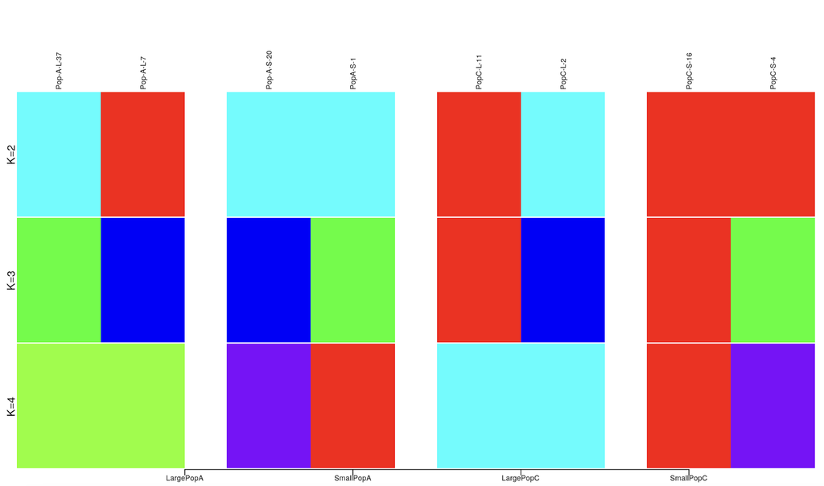

Fig 1. Admixture plot.

To determine the best K. Check your cross-validation error report. The K with the lowest value should be your best K.

### Note:

Remember that ADMIXTURE/STRUCTURE plots can be quite misleading as different demographic histories can lead to the same results (see. e.g. Lawson et al, 2018) These plots are great to detect recent hybrids but they are not ideal to infer complex demographic histories with hybrid origins of entire populations

To evaluate if the ADMIXTURE plot is a good fit, you can use `evaladmix` and we highly recommend to also use other methods to help infer the demographic history and evidence of ´hybridisation`such as`Dstatistics`, demographic modeling etc.

### 3. Estimating and understanding Fst

This tutorial provides an overview of *Fst (Fixation Index)*, a key population genetics statistic used to measure genetic differentiation between subpopulations. It explains how `Fst` quantifies population structure, helping to determine whether genetic variation is distributed within or among populations. Various estimation methods, such as Weir & Cockerham’s Fst, are discussed, along with their applications. This tutorial also covers the interpretation of `Fst values`, where higher values indicate greater genetic differentiation due to limited gene flow, while lower values suggest more genetic mixing. Finally, it provides practical guidance on computing Fst using R packages like `adegenet` and `hierfstat`, making it a valuable resource for researchers studying population structure in ecology, evolution, and conservation genetics.

## 3.1. Converting .bed file (pruned; unlinked) to .vcf file

First, convert your pruned SNP file to .vcf file using plink

```bash
plink --bfile milkfish_nomaf_Pruned --allow-extra-chr 0 --recode vcf --out milkfish_nomaf_Pruned_vcf
```

Then count the number of unlinked SNPs on your vcf for your reference

```bash
bcftools veiw -H milkfish_nomaf_Pruned_vcf.vcf | wc -l
```

### 3.2. Computing and plotting pairwise FST (Weir & Cockerham 1984)

Go to your R studio and make sure these R packages are `installed` and `loaded`

```r
install.packages(c("vcfR", "adegenet"))
install.packages("poppr")
install.packages("hierfstat")
install.packages("reshape2")
install.packages("dplyr")
install.packages("RColorBrewer")
install.packages("MASS")
```

```r
library(vcfR)
library(adegenet)
library(poppr)
library(hierfstat)
library(reshape2)
```

```r
library(ggplot2)
library(dplyr)
library(RColorBrewer)
library(MASS)
```

### 3.3 Load and view your vcf file

```r
milkfish = read.VCF("milkfish_filtered_PrunedUnrel_vcf.vcf")
```

```
## ped stats and snps stats have been set.
## 'p' has been set.
## 'mu' and 'sigma' have been set.
```

```r
str(milkfish)
```

```
## Formal class 'bed.matrix' [package "gaston"] with 8 slots
##   ..@ ped                 :'data.frame': 8 obs. of  30 variables:
##   .. ..$ famid      : chr [1:8] "Pop-A-L-37_Pop-A-L-37" "Pop-A-L-7_Pop-A-L-7" "Pop-A-S-20_Pop-A-S-20" "PopA-S-1_PopA-S-1" ...
##   .. ..$ id         : chr [1:8] "Pop-A-L-37_Pop-A-L-37" "Pop-A-L-7_Pop-A-L-7" "Pop-A-S-20_Pop-A-S-20" "PopA-S-1_PopA-S-1" ...
##   .. ..$ father     : num [1:8] 0 0 0 0 0 0 0 0
##   .. ..$ mother     : num [1:8] 0 0 0 0 0 0 0 0
##   .. ..$ sex        : num [1:8] 0 0 0 0 0 0 0 0
##   .. ..$ pheno      : logi [1:8] NA NA NA NA NA NA ...
##   .. ..$ N0         : int [1:8] 2009 1955 1992 1836 1757 2007 2006 1950
##   .. ..$ N1         : int [1:8] 345 316 537 697 188 269 293 278
##   .. ..$ N2         : int [1:8] 1324 1334 1257 1176 1251 1173 1273 1256
##   .. ..$ NAs        : int [1:8] 367 440 259 336 849 596 473 561
##   .. ..$ N0.x       : int [1:8] 0 0 0 0 0 0 0 0
##   .. ..$ N1.x       : int [1:8] 0 0 0 0 0 0 0 0
##   .. ..$ N2.x       : int [1:8] 0 0 0 0 0 0 0 0
##   .. ..$ NAs.x      : int [1:8] 0 0 0 0 0 0 0 0
##   .. ..$ N0.y       : int [1:8] 0 0 0 0 0 0 0 0
##   .. ..$ N1.y       : int [1:8] 0 0 0 0 0 0 0 0
##   .. ..$ N2.y       : int [1:8] 0 0 0 0 0 0 0 0
##   .. ..$ NAs.y      : int [1:8] 0 0 0 0 0 0 0 0
##   .. ..$ N0.mt      : int [1:8] 0 0 0 0 0 0 0 0
##   .. ..$ N1.mt      : int [1:8] 0 0 0 0 0 0 0 0
##   .. ..$ N2.mt      : int [1:8] 0 0 0 0 0 0 0 0
##   .. ..$ NAs.mt     : int [1:8] 0 0 0 0 0 0 0 0
##   .. ..$ callrate   : num [1:8] -Inf -Inf -Inf -Inf -Inf ...
##   .. ..$ hz         : num [1:8] -0.94 -0.718 -2.073 -2.074 -0.221 ...
##   .. ..$ callrate.x : num [1:8] NaN NaN NaN NaN NaN NaN NaN NaN
##   .. ..$ hz.x       : num [1:8] NaN NaN NaN NaN NaN NaN NaN NaN
##   .. ..$ callrate.y : num [1:8] NaN NaN NaN NaN NaN NaN NaN NaN
##   .. ..$ hz.y       : num [1:8] NaN NaN NaN NaN NaN NaN NaN NaN
##   .. ..$ callrate.mt: num [1:8] NaN NaN NaN NaN NaN NaN NaN NaN
##   .. ..$ hz.mt      : num [1:8] NaN NaN NaN NaN NaN NaN NaN NaN
##   ..@ snps                :'data.frame': 4045 obs. of  19 variables:
##   .. ..$ chr     : int [1:4045] 0 0 0 0 0 0 0 0 0 0 ...
##   .. ..$ id      : chr [1:4045] "CABIVO010000001.1:107709" "CABIVO010000001.1:116114" "CABIVO010000001.1:158081" "CABIVO010000002.1:116396" ...
##   .. ..$ dist    : num [1:4045] 0 0 0 0 0 0 0 0 0 0 ...
##   .. ..$ pos     : int [1:4045] 107709 116114 158081 116396 563810 800260 254674 259061 72366 239178 ...
##   .. ..$ A1      : chr [1:4045] "G" "G" "G" "A" ...
##   .. ..$ A2      : chr [1:4045] "A" "A" "A" "T" ...
##   .. ..$ quality : num [1:4045] 0 0 0 0 0 0 0 0 0 0 ...
##   .. ..$ filter  : Factor w/ 1 level ".": 1 1 1 1 1 1 1 1 1 1 ...
##   .. ..$ N0      : int [1:4045] 4 3 3 3 3 3 4 4 5 3 ...
##   .. ..$ N1      : int [1:4045] 1 1 1 1 1 1 0 0 0 1 ...
##   .. ..$ N2      : int [1:4045] 3 3 3 3 3 3 3 3 2 3 ...
##   .. ..$ NAs     : int [1:4045] 0 1 1 1 1 1 1 1 1 1 ...
##   .. ..$ N0.f    : int [1:4045] NA NA NA NA NA NA NA NA NA NA ...
##   .. ..$ N1.f    : int [1:4045] NA NA NA NA NA NA NA NA NA NA ...
##   .. ..$ N2.f    : int [1:4045] NA NA NA NA NA NA NA NA NA NA ...
##   .. ..$ NAs.f   : int [1:4045] NA NA NA NA NA NA NA NA NA NA ...
##   .. ..$ callrate: num [1:4045] 1 0.875 0.875 0.875 0.875 0.875 0.875 0.875 0.875 0.875 ...
##   .. ..$ maf     : num [1:4045] 0.438 0.5 0.5 0.5 0.5 ...
##   .. ..$ hz      : num [1:4045] 0.125 0.143 0.143 0.143 0.143 ...
##   ..@ bed                 :<externalptr>
##   ..@ p                   : num [1:4045] 0.438 0.5 0.5 0.5 0.5 ...
##   ..@ mu                  : num [1:4045] 0.875 1 1 1 1 ...
##   ..@ sigma               : num [1:4045] 0.991 0.926 0.926 0.926 0.926 ...
##   ..@ standardize_p       : logi FALSE
##   ..@ standardize_mu_sigma: logi FALSE
```

### 3.4. Reformat VCF file and convert to genid (.gen) object

```r
#convert .vcf to a vcf object
vcf_obj <- read.vcfR("milkfish_filtered_PrunedUnrel_vcf.vcf")
```

```
## Scanning file to determine attributes.
## File attributes:
##   meta lines: 6
##   header_line: 7
##   variant count: 4045
##   column count: 17
## Meta line 6 read in.
## All meta lines processed.
## gt matrix initialized.
## Character matrix gt created.
##   Character matrix gt rows: 4045
##   Character matrix gt cols: 17
##   skip: 0
##   nrows: 4045
##   row_num: 0
## Processed variant 1000Processed variant 2000Processed variant 3000Processed variant 4000Processed variant: 4045
## All variants processed
```

```r
# extract genotypes and convert to data frame

# Extract genotypes
genotypes <- extract.gt(vcf_obj)
# Convert to a data frame
df_genotypes <- as.data.frame(t(genotypes))

# Replace multiple dots in column names with underscores
colnames(df_genotypes) <- gsub("\\.+", "_", colnames(df_genotypes))

#Convert the data frame to genid object

# Convert the data frame to a genind object
milkfish_genind <- df2genind(df_genotypes, sep = "/", ploidy = 2)
```

You should have a .gen (genid) file (milkfish_genind) at the end of all these commands.

To check just type:

```r
milkfish_genind
```

```
## /// GENIND OBJECT /////////
##
##  // 8 individuals; 4,045 loci; 8,090 alleles; size: 2.7 Mb
##
##  // Basic content
##    @tab:  8 x 8090 matrix of allele counts
##    @loc.n.all: number of alleles per locus (range: 2-2)
##    @loc.fac: locus factor for the 8090 columns of @tab
##    @all.names: list of allele names for each locus
##    @ploidy: ploidy of each individual  (range: 2-2)
##    @type:  codom
##    @call: df2genind(X = df_genotypes, sep = "/", ploidy = 2)
##
##  // Optional content
##    - empty -
```

You should see something similar to this!

### 3.5. Calculate pairwise FST

```r
##First assign populations manually
# Example: Assigning populations (assuming 8 individuals belong to 2 populations and 2 growth phenotype categories)

pop_vector <- c("Large_A", "Large_A", "Small_A", "Small_A", "Large_C", "Large_C", "Small_C", "Small_C")

milkfish_genind@pop <- as.factor(pop_vector)

##Print the sample size for each site to check if the assingment is correct
##You should see 2 individuals per population / category group (4 in total)

summary(milkfish_genind$pop)
```

```
## Large_A Large_C Small_A Small_C
##       2       2       2       2
```

Computer your FST

```r
milkfish_fst = genet.dist(milkfish_genind, method = "WC84") %>% round(digits = 3)

#view
milkfish_fst
```

```
##         Large_A Large_C Small_A
## Large_C   0.014
## Small_A   0.002   0.007
## Small_C   0.005  -0.025   0.005
```

```r
##Takes around 15 mins depending on the power of your laptop
```

To visualize you pairwise FST results

```r
# Desired order of labels
lab_order = c("Large_A","Large_C","Small_A","Small_C")

# Change order of rows and cols
fst.mat = as.matrix(milkfish_fst)
fst.mat1 = fst.mat[lab_order, ]
fst.mat2 = fst.mat1[, lab_order]

# Create a data.frame
ind = which(upper.tri(fst.mat2), arr.ind = TRUE)
fst.df = data.frame(Site1 = dimnames(fst.mat2)[[2]][ind[,2]],
                    Site2 = dimnames(fst.mat2)[[1]][ind[,1]],
                    Fst = fst.mat2[ ind ])

# Keep the order of the levels in the data.frame for plotting
fst.df$Site1 = factor(fst.df$Site1, levels = unique(fst.df$Site1))
fst.df$Site2 = factor(fst.df$Site2, levels = unique(fst.df$Site2))

# Convert minus values to zero
fst.df$Fst[fst.df$Fst < 0] = 0

# Print data.frame summary
fst.df %>% str
```

```
## 'data.frame':    6 obs. of  3 variables:
##  $ Site1: Factor w/ 3 levels "Large_C","Small_A",..: 1 2 2 3 3 3
##  $ Site2: Factor w/ 3 levels "Large_A","Large_C",..: 1 1 2 1 2 3
##  $ Fst  : num  0.014 0.002 0.007 0.005 0 0.005
```

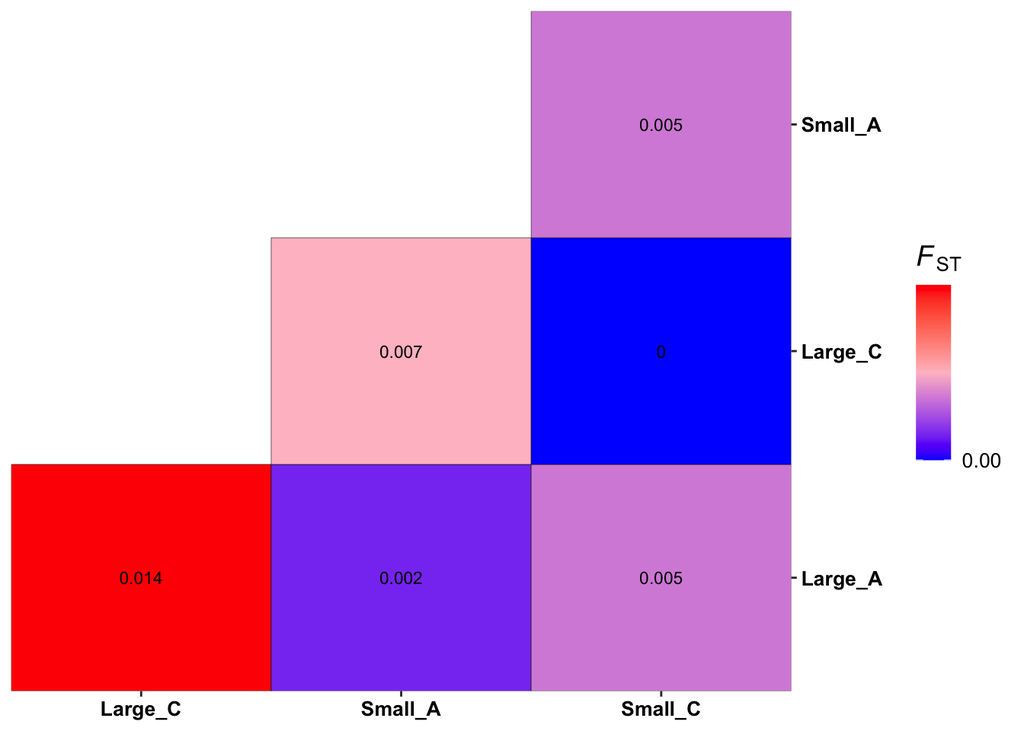

```r
## 'data.frame':    15 obs. of  3 variables:
##  $ Site1: Factor w/ 5 levels "Brd","Pad","Vig",..: 1 2 2 3 3 3 4 4 4 4 ...
##  $ Site2: Factor w/ 5 levels "Ber","Brd","Pad",..: 1 1 2 1 2 3 1 2 3 4 ...
##  $ Fst  : num  0.007 0.025 0.008 0.064 0.038 0.018 0.174 0.171 0.161 0.112 ...

# Fst italic label
fst.label = expression(italic("F")[ST])

# Extract middle Fst value for gradient argument
mid = max(fst.df$Fst) / 2

# Plot heatmap
ggplot(data = fst.df, aes(x = Site1, y = Site2, fill = Fst))+
  geom_tile(colour = "black")+
  geom_text(aes(label = Fst), color="black", size = 3)+
  scale_fill_gradient2(low = "blue", mid = "pink", high = "red", midpoint = mid, name = fst.label, limits = c(0, max(fst.df$Fst)), breaks = c(0, 0.05, 0.10, 0.15))+
  scale_x_discrete(expand = c(0,0))+
  scale_y_discrete(expand = c(0,0), position = "right")+
  theme(axis.text = element_text(colour = "black", size = 10, face = "bold"),
        axis.title = element_blank(),
        panel.grid = element_blank(),
        panel.background = element_blank(),
        legend.position = "right",
        legend.title = element_text(size = 14, face = "bold"),
        legend.text = element_text(size = 10)
  )
```

## Congratulaations you have performed, PCA, Admixture, pairwise FST analysis

## We will discuss the results / interpretation of results afterwards!!!